# Camera-Up Yaw Stability Experiment

True yaw is intentionally held constant. The transformed image simulates a camera above the eye (+5/+10 deg), then the trained model is used to compare old and new yaw predictions. Aggregate plots use all rows; the image viewer shows 50 of 50 rows.

**Samples**50

**Old mean abs yaw error**1.82 deg

**New mean abs yaw error**2.01 deg

**Mean new-old yaw delta**-0.04 deg

## Model Analysis Plots

### Old Prediction vs True Yaw

[figure not shown]

### New Prediction vs True Yaw

[figure not shown]

### New vs Old Predicted Yaw

[figure not shown]

### New vs Old Predicted Yaw Delta by Sample

[figure not shown]

### Old/New Absolute Error Against True Yaw

[figure not shown]

## Aggregate Table

| Metric | Mean | Median | Std |
| --- | --- | --- | --- |
| Old Prediction vs True Yaw abs error | 1.819 | 1.070 | 2.035 |
| New Prediction vs True Yaw abs error | 2.011 | 1.513 | 2.096 |
| New vs Old Predicted Yaw delta | -0.045 | 0.034 | 0.898 |

## Original vs Transformed Eye Patch

Sample 1 / 50

**p08-day05-left-00214** +5 deg camera-up effect

Sample 1 / 50 visualized

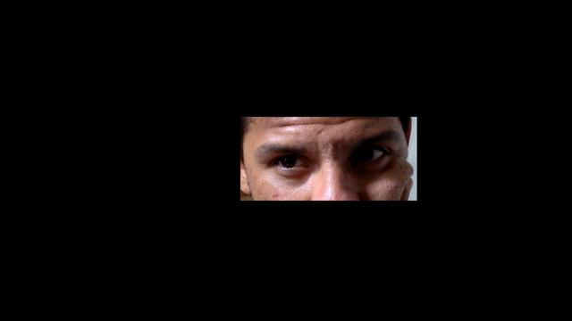

Original Source Frame

Normalized Eye Patch

Transformed Eye Patch

Pixel Difference

**True yaw**5.47 deg

**Old Prediction vs True Yaw**8.81 deg / error 3.35

**New Prediction vs True Yaw**7.21 deg / error 1.74

**New vs Old Predicted Yaw**delta -1.61 deg

**p00-day01-right-00596** +5 deg camera-up effect

Sample 2 / 50 visualized

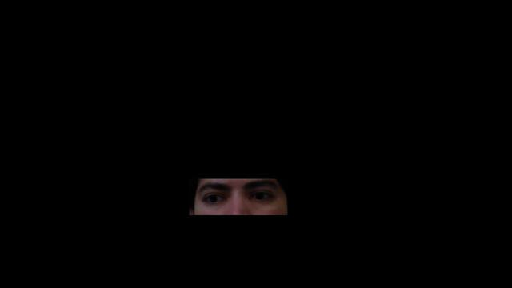

Original Source Frame

Normalized Eye Patch

Transformed Eye Patch

Pixel Difference

**True yaw**14.34 deg

**Old Prediction vs True Yaw**14.20 deg / error 0.14

**New Prediction vs True Yaw**14.75 deg / error 0.41

**New vs Old Predicted Yaw**delta +0.55 deg

**p02-day07-right-00451** +10 deg camera-up effect

Sample 3 / 50 visualized

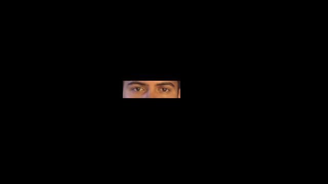

Original Source Frame

Normalized Eye Patch

Transformed Eye Patch

Pixel Difference

**True yaw**-2.38 deg

**Old Prediction vs True Yaw**-0.85 deg / error 1.54

**New Prediction vs True Yaw**0.15 deg / error 2.53

**New vs Old Predicted Yaw**delta +1.00 deg

**p03-day56-left-01745** +5 deg camera-up effect

Sample 4 / 50 visualized

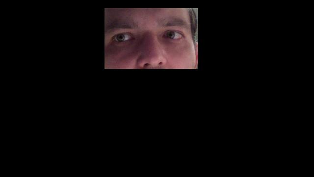

Original Source Frame

Normalized Eye Patch

Transformed Eye Patch

Pixel Difference

**True yaw**10.53 deg

**Old Prediction vs True Yaw**11.23 deg / error 0.69

**New Prediction vs True Yaw**10.05 deg / error 0.49

**New vs Old Predicted Yaw**delta -1.18 deg

**p02-day22-left-01031** +5 deg camera-up effect

Sample 5 / 50 visualized

[figure not shown]

Original Source Frame

Normalized Eye Patch

Transformed Eye Patch

Pixel Difference

**True yaw**0.46 deg

**Old Prediction vs True Yaw**3.23 deg / error 2.76

**New Prediction vs True Yaw**3.04 deg / error 2.58

**New vs Old Predicted Yaw**delta -0.19 deg

**p07-day25-right-00120** +5 deg camera-up effect

Sample 6 / 50 visualized

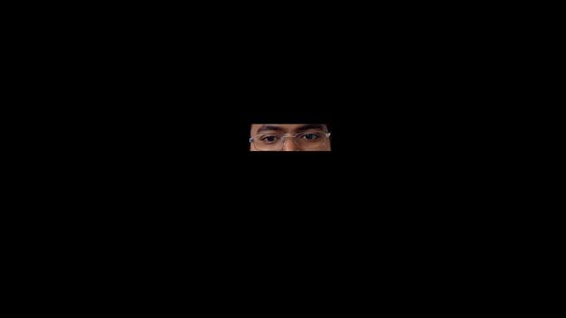

Original Source Frame

Normalized Eye Patch

Transformed Eye Patch

Pixel Difference

**True yaw**5.53 deg

**Old Prediction vs True Yaw**-0.51 deg / error 6.04

**New Prediction vs True Yaw**-0.39 deg / error 5.92

**New vs Old Predicted Yaw**delta +0.12 deg

**p04-day23-right-00258** +5 deg camera-up effect

Sample 7 / 50 visualized

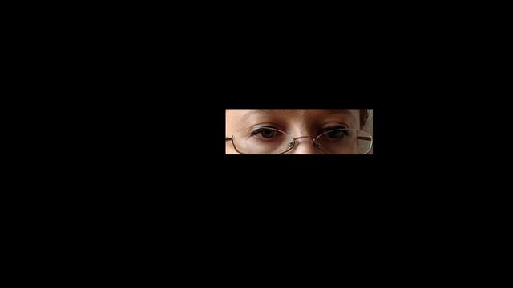

Original Source Frame

Normalized Eye Patch

Transformed Eye Patch

Pixel Difference

**True yaw**-9.50 deg

**Old Prediction vs True Yaw**-8.75 deg / error 0.75

**New Prediction vs True Yaw**-8.75 deg / error 0.75

**New vs Old Predicted Yaw**delta +0.00 deg

**p02-day22-left-01099** +5 deg camera-up effect

Sample 8 / 50 visualized

[figure not shown]

Original Source Frame

Normalized Eye Patch

Transformed Eye Patch

Pixel Difference

**True yaw**2.27 deg

**Old Prediction vs True Yaw**6.08 deg / error 3.81

**New Prediction vs True Yaw**5.88 deg / error 3.61

**New vs Old Predicted Yaw**delta -0.20 deg

**p09-day03-left-00380** +10 deg camera-up effect

Sample 9 / 50 visualized

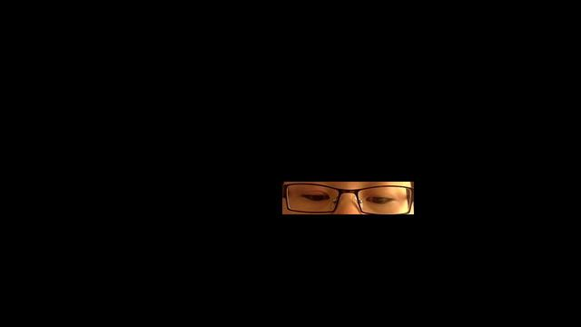

Original Source Frame

Normalized Eye Patch

Transformed Eye Patch

Pixel Difference

**True yaw**-2.99 deg

**Old Prediction vs True Yaw**-2.69 deg / error 0.30

**New Prediction vs True Yaw**-3.60 deg / error 0.60

**New vs Old Predicted Yaw**delta -0.91 deg

**p04-day17-right-00725** +5 deg camera-up effect

Sample 10 / 50 visualized

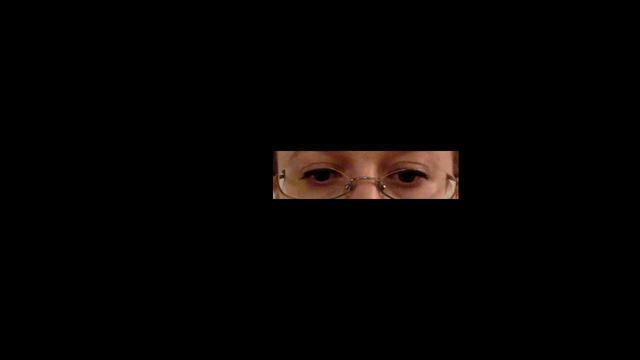

Original Source Frame

Normalized Eye Patch

Transformed Eye Patch

Pixel Difference

**True yaw**-0.86 deg

**Old Prediction vs True Yaw**-1.67 deg / error 0.81

**New Prediction vs True Yaw**-1.19 deg / error 0.33

**New vs Old Predicted Yaw**delta +0.48 deg

**p07-day42-right-00156** +5 deg camera-up effect

Sample 11 / 50 visualized

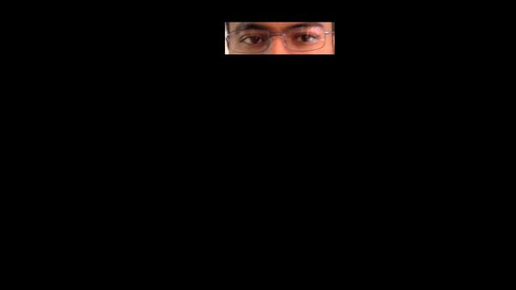

Original Source Frame

Normalized Eye Patch

Transformed Eye Patch

Pixel Difference

**True yaw**-8.63 deg

**Old Prediction vs True Yaw**-11.34 deg / error 2.71

**New Prediction vs True Yaw**-11.04 deg / error 2.40

**New vs Old Predicted Yaw**delta +0.31 deg

**p00-day31-right-00668** +5 deg camera-up effect

Sample 12 / 50 visualized

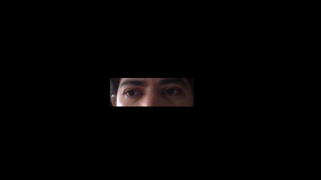

Original Source Frame

Normalized Eye Patch

Transformed Eye Patch

Pixel Difference

**True yaw**14.40 deg

**Old Prediction vs True Yaw**13.82 deg / error 0.57

**New Prediction vs True Yaw**14.63 deg / error 0.23

**New vs Old Predicted Yaw**delta +0.80 deg

**p00-day09-left-00420** +5 deg camera-up effect

Sample 13 / 50 visualized

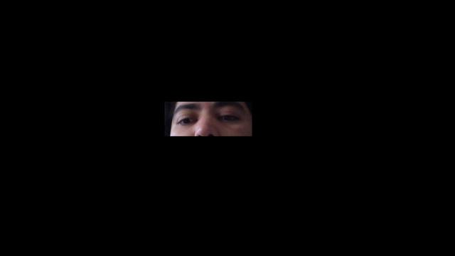

Original Source Frame

Normalized Eye Patch

Transformed Eye Patch

Pixel Difference

**True yaw**12.79 deg

**Old Prediction vs True Yaw**11.33 deg / error 1.46

**New Prediction vs True Yaw**11.69 deg / error 1.10

**New vs Old Predicted Yaw**delta +0.36 deg

**p01-day01-right-00084** +5 deg camera-up effect

Sample 14 / 50 visualized

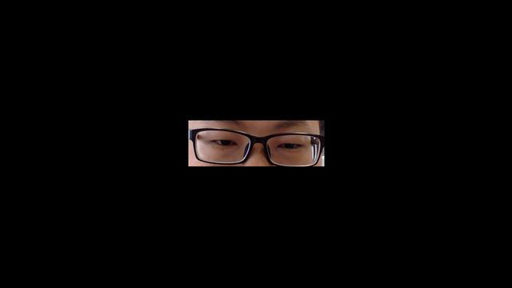

Original Source Frame

Normalized Eye Patch

Transformed Eye Patch

Pixel Difference

**True yaw**-4.19 deg

**Old Prediction vs True Yaw**-3.51 deg / error 0.69

**New Prediction vs True Yaw**-3.83 deg / error 0.36

**New vs Old Predicted Yaw**delta -0.32 deg

**p01-day42-right-00409** +5 deg camera-up effect

Sample 15 / 50 visualized

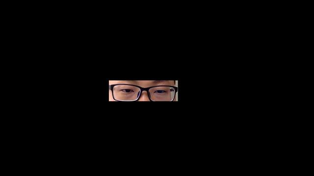

Original Source Frame

Normalized Eye Patch

Transformed Eye Patch

Pixel Difference

**True yaw**-5.46 deg

**Old Prediction vs True Yaw**-5.08 deg / error 0.38

**New Prediction vs True Yaw**-5.35 deg / error 0.11

**New vs Old Predicted Yaw**delta -0.27 deg

**p01-day63-left-00317** +5 deg camera-up effect

Sample 16 / 50 visualized

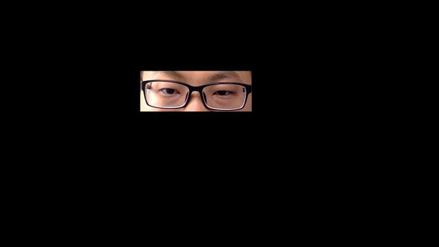

Original Source Frame

Normalized Eye Patch

Transformed Eye Patch

Pixel Difference

**True yaw**4.83 deg

**Old Prediction vs True Yaw**3.71 deg / error 1.12

**New Prediction vs True Yaw**4.07 deg / error 0.76

**New vs Old Predicted Yaw**delta +0.36 deg

**p05-day05-left-00017** +10 deg camera-up effect

Sample 17 / 50 visualized

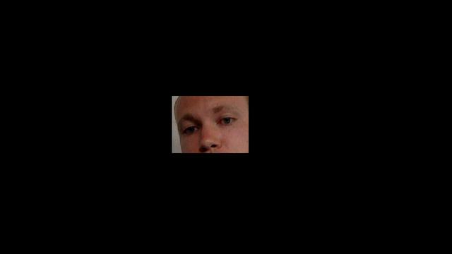

Original Source Frame

Normalized Eye Patch

Transformed Eye Patch

Pixel Difference

**True yaw**1.40 deg

**Old Prediction vs True Yaw**-0.92 deg / error 2.32

**New Prediction vs True Yaw**-2.52 deg / error 3.92

**New vs Old Predicted Yaw**delta -1.61 deg

**p08-day10-right-00052** +5 deg camera-up effect

Sample 18 / 50 visualized

[figure not shown]

Original Source Frame

Normalized Eye Patch

Transformed Eye Patch

Pixel Difference

**True yaw**0.05 deg

**Old Prediction vs True Yaw**-9.83 deg / error 9.88

**New Prediction vs True Yaw**-8.70 deg / error 8.76

**New vs Old Predicted Yaw**delta +1.12 deg

**p00-day17-left-00827** +10 deg camera-up effect

Sample 19 / 50 visualized

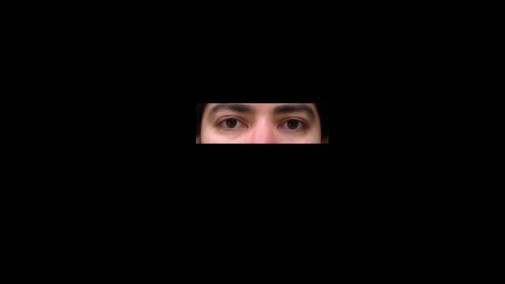

Original Source Frame

Normalized Eye Patch

Transformed Eye Patch

Pixel Difference

**True yaw**2.45 deg

**Old Prediction vs True Yaw**4.01 deg / error 1.55

**New Prediction vs True Yaw**3.87 deg / error 1.42

**New vs Old Predicted Yaw**delta -0.14 deg

**p08-day21-left-00663** +10 deg camera-up effect

Sample 20 / 50 visualized

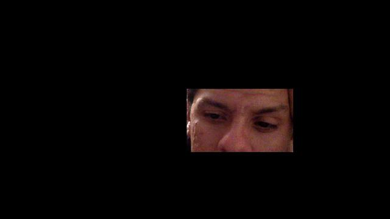

Original Source Frame

Normalized Eye Patch

Transformed Eye Patch

Pixel Difference

**True yaw**9.22 deg

**Old Prediction vs True Yaw**4.50 deg / error 4.72

**New Prediction vs True Yaw**3.28 deg / error 5.94

**New vs Old Predicted Yaw**delta -1.22 deg

**p03-day57-right-00148** +5 deg camera-up effect

Sample 21 / 50 visualized

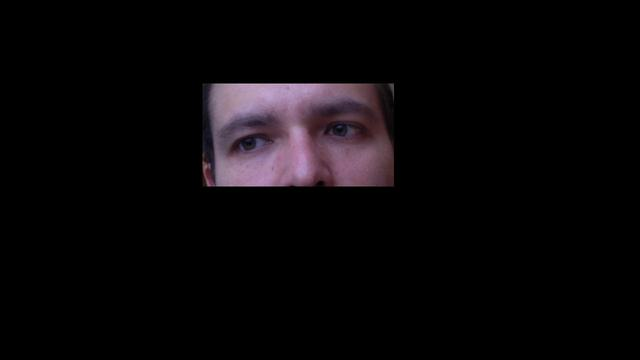

Original Source Frame

Normalized Eye Patch

Transformed Eye Patch

Pixel Difference

**True yaw**14.56 deg

**Old Prediction vs True Yaw**15.47 deg / error 0.91

**New Prediction vs True Yaw**15.59 deg / error 1.03

**New vs Old Predicted Yaw**delta +0.12 deg

**p03-day52-left-00186** +5 deg camera-up effect

Sample 22 / 50 visualized

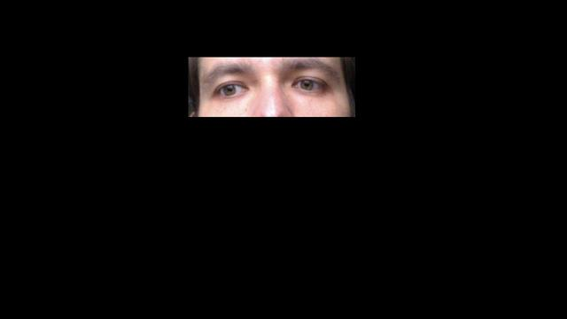

Original Source Frame

Normalized Eye Patch

Transformed Eye Patch

Pixel Difference

**True yaw**10.09 deg

**Old Prediction vs True Yaw**11.63 deg / error 1.54

**New Prediction vs True Yaw**11.80 deg / error 1.71

**New vs Old Predicted Yaw**delta +0.18 deg

**p00-day34-left-00194** +10 deg camera-up effect

Sample 23 / 50 visualized

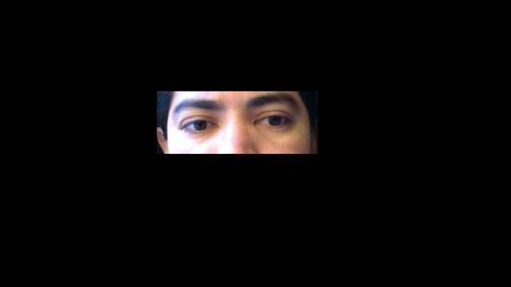

Original Source Frame

Normalized Eye Patch

Transformed Eye Patch

Pixel Difference

**True yaw**-1.78 deg

**Old Prediction vs True Yaw**-2.04 deg / error 0.26

**New Prediction vs True Yaw**-3.72 deg / error 1.95

**New vs Old Predicted Yaw**delta -1.69 deg

**p07-day10-right-00047** +10 deg camera-up effect

Sample 24 / 50 visualized

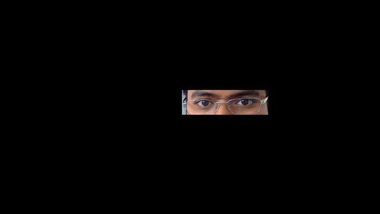

Original Source Frame

Normalized Eye Patch

Transformed Eye Patch

Pixel Difference

**True yaw**-0.19 deg

**Old Prediction vs True Yaw**-2.72 deg / error 2.53

**New Prediction vs True Yaw**-4.71 deg / error 4.52

**New vs Old Predicted Yaw**delta -2.00 deg

**p04-day08-right-00317** +10 deg camera-up effect

Sample 25 / 50 visualized

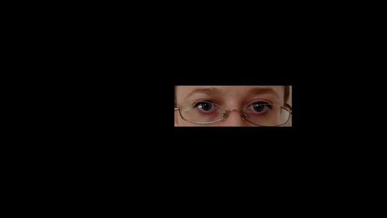

Original Source Frame

Normalized Eye Patch

Transformed Eye Patch

Pixel Difference

**True yaw**-2.98 deg

**Old Prediction vs True Yaw**-3.39 deg / error 0.41

**New Prediction vs True Yaw**-2.94 deg / error 0.05

**New vs Old Predicted Yaw**delta +0.45 deg

**p02-day10-right-00574** +5 deg camera-up effect

Sample 26 / 50 visualized

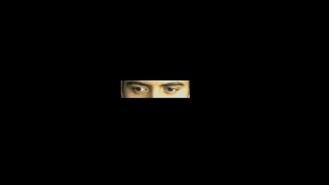

Original Source Frame

Normalized Eye Patch

Transformed Eye Patch

Pixel Difference

**True yaw**10.79 deg

**Old Prediction vs True Yaw**10.89 deg / error 0.10

**New Prediction vs True Yaw**11.67 deg / error 0.88

**New vs Old Predicted Yaw**delta +0.78 deg

**p09-day12-right-00005** +5 deg camera-up effect

Sample 27 / 50 visualized

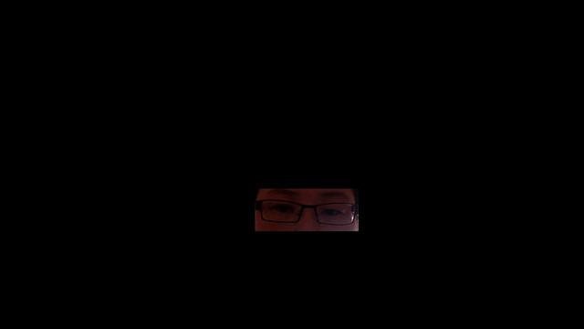

Original Source Frame

Normalized Eye Patch

Transformed Eye Patch

Pixel Difference

**True yaw**1.32 deg

**Old Prediction vs True Yaw**3.41 deg / error 2.09

**New Prediction vs True Yaw**5.12 deg / error 3.81

**New vs Old Predicted Yaw**delta +1.71 deg

**p05-day03-right-00056** +10 deg camera-up effect

Sample 28 / 50 visualized

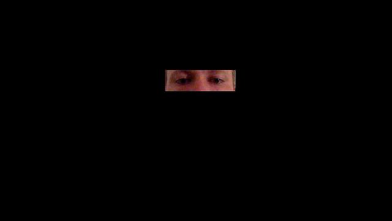

Original Source Frame

Normalized Eye Patch

Transformed Eye Patch

Pixel Difference

**True yaw**-4.92 deg

**Old Prediction vs True Yaw**-2.85 deg / error 2.07

**New Prediction vs True Yaw**-3.00 deg / error 1.92

**New vs Old Predicted Yaw**delta -0.15 deg

**p00-day37-right-00510** +5 deg camera-up effect

Sample 29 / 50 visualized

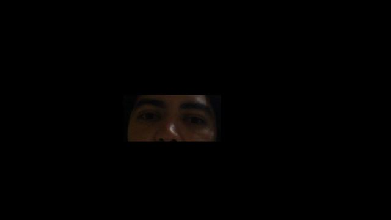

Original Source Frame

Normalized Eye Patch

Transformed Eye Patch

Pixel Difference

**True yaw**3.01 deg

**Old Prediction vs True Yaw**2.64 deg / error 0.37

**New Prediction vs True Yaw**3.89 deg / error 0.88

**New vs Old Predicted Yaw**delta +1.25 deg

**p02-day25-left-00174** +5 deg camera-up effect

Sample 30 / 50 visualized

[figure not shown]

Original Source Frame

Normalized Eye Patch

Transformed Eye Patch

Pixel Difference

**True yaw**-4.36 deg

**Old Prediction vs True Yaw**-3.10 deg / error 1.26

**New Prediction vs True Yaw**-4.34 deg / error 0.01

**New vs Old Predicted Yaw**delta -1.24 deg

**p08-day30-left-00208** +10 deg camera-up effect

Sample 31 / 50 visualized

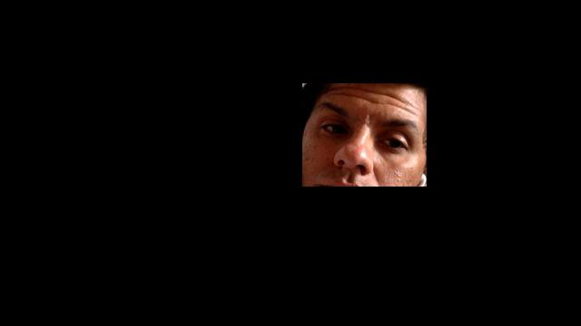

Original Source Frame

Normalized Eye Patch

Transformed Eye Patch

Pixel Difference

**True yaw**-14.23 deg

**Old Prediction vs True Yaw**-14.52 deg / error 0.29

**New Prediction vs True Yaw**-15.10 deg / error 0.87

**New vs Old Predicted Yaw**delta -0.59 deg

**p06-day61-right-00249** +5 deg camera-up effect

Sample 32 / 50 visualized

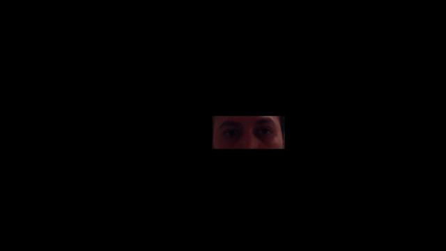

Original Source Frame

Normalized Eye Patch

Transformed Eye Patch

Pixel Difference

**True yaw**-6.94 deg

**Old Prediction vs True Yaw**-2.98 deg / error 3.96

**New Prediction vs True Yaw**-2.25 deg / error 4.68

**New vs Old Predicted Yaw**delta +0.72 deg

**p09-day03-right-00236** +10 deg camera-up effect

Sample 33 / 50 visualized

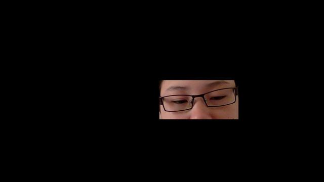

Original Source Frame

Normalized Eye Patch

Transformed Eye Patch

Pixel Difference

**True yaw**-6.64 deg

**Old Prediction vs True Yaw**-8.01 deg / error 1.37

**New Prediction vs True Yaw**-8.57 deg / error 1.94

**New vs Old Predicted Yaw**delta -0.57 deg

**p03-day59-left-00035** +10 deg camera-up effect

Sample 34 / 50 visualized

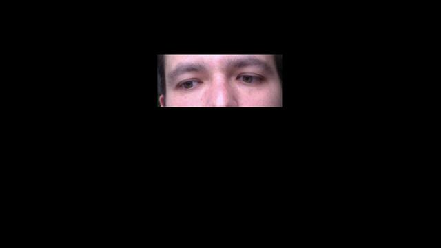

Original Source Frame

Normalized Eye Patch

Transformed Eye Patch

Pixel Difference

**True yaw**13.86 deg

**Old Prediction vs True Yaw**16.10 deg / error 2.25

**New Prediction vs True Yaw**16.02 deg / error 2.16

**New vs Old Predicted Yaw**delta -0.09 deg

**p04-day06-right-00318** +10 deg camera-up effect

Sample 35 / 50 visualized

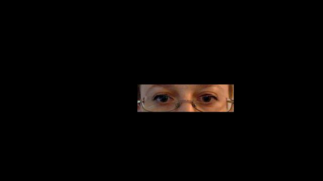

Original Source Frame

Normalized Eye Patch

Transformed Eye Patch

Pixel Difference

**True yaw**-1.97 deg

**Old Prediction vs True Yaw**-2.15 deg / error 0.18

**New Prediction vs True Yaw**-0.66 deg / error 1.31

**New vs Old Predicted Yaw**delta +1.48 deg

**p03-day54-left-00311** +5 deg camera-up effect

Sample 36 / 50 visualized

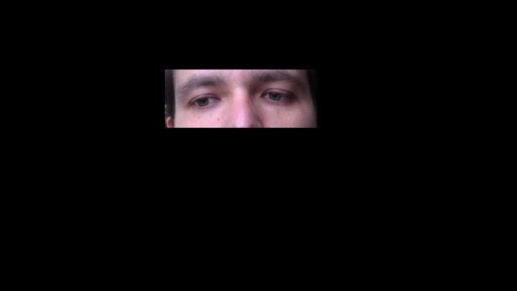

Original Source Frame

Normalized Eye Patch

Transformed Eye Patch

Pixel Difference

**True yaw**11.89 deg

**Old Prediction vs True Yaw**16.07 deg / error 4.18

**New Prediction vs True Yaw**16.17 deg / error 4.28

**New vs Old Predicted Yaw**delta +0.10 deg

**p03-day36-left-00725** +10 deg camera-up effect

Sample 37 / 50 visualized

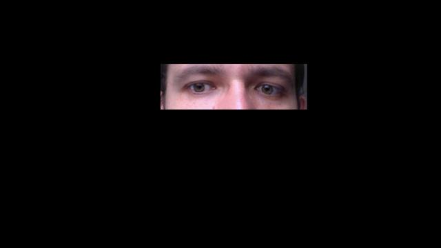

Original Source Frame

Normalized Eye Patch

Transformed Eye Patch

Pixel Difference

**True yaw**6.45 deg

**Old Prediction vs True Yaw**15.11 deg / error 8.66

**New Prediction vs True Yaw**16.03 deg / error 9.58

**New vs Old Predicted Yaw**delta +0.92 deg

**p04-day19-right-00229** +5 deg camera-up effect

Sample 38 / 50 visualized

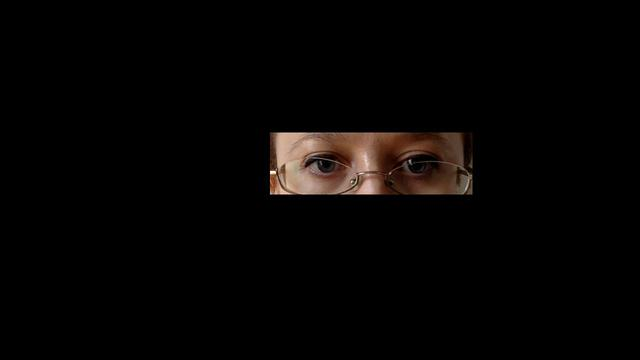

Original Source Frame

Normalized Eye Patch

Transformed Eye Patch

Pixel Difference

**True yaw**-4.25 deg

**Old Prediction vs True Yaw**-4.34 deg / error 0.09

**New Prediction vs True Yaw**-4.19 deg / error 0.06

**New vs Old Predicted Yaw**delta +0.14 deg

**p00-day15-right-00207** +10 deg camera-up effect

Sample 39 / 50 visualized

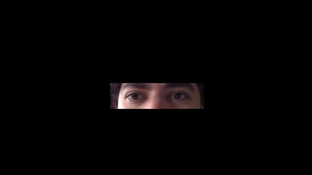

Original Source Frame

Normalized Eye Patch

Transformed Eye Patch

Pixel Difference

**True yaw**7.44 deg

**Old Prediction vs True Yaw**8.10 deg / error 0.67

**New Prediction vs True Yaw**10.01 deg / error 2.58

**New vs Old Predicted Yaw**delta +1.91 deg

**p01-day47-left-00324** +5 deg camera-up effect

Sample 40 / 50 visualized

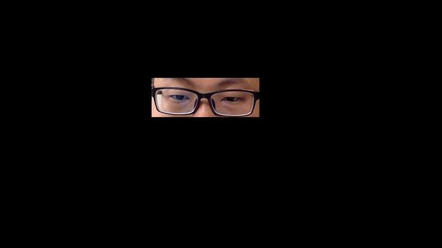

Original Source Frame

Normalized Eye Patch

Transformed Eye Patch

Pixel Difference

**True yaw**5.18 deg

**Old Prediction vs True Yaw**5.38 deg / error 0.20

**New Prediction vs True Yaw**4.96 deg / error 0.22

**New vs Old Predicted Yaw**delta -0.42 deg

**p03-day19-left-00004** +10 deg camera-up effect

Sample 41 / 50 visualized

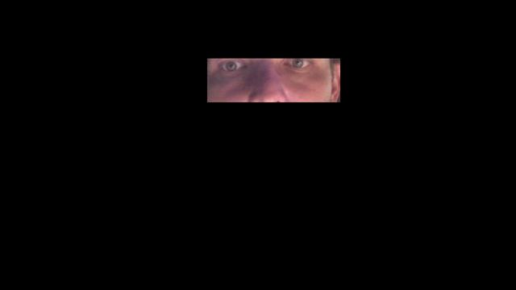

Original Source Frame

Normalized Eye Patch

Transformed Eye Patch

Pixel Difference

**True yaw**4.92 deg

**Old Prediction vs True Yaw**4.45 deg / error 0.47

**New Prediction vs True Yaw**2.85 deg / error 2.07

**New vs Old Predicted Yaw**delta -1.60 deg

**p07-day09-left-00393** +10 deg camera-up effect

Sample 42 / 50 visualized

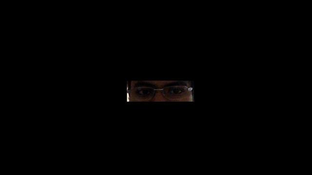

Original Source Frame

Normalized Eye Patch

Transformed Eye Patch

Pixel Difference

**True yaw**-4.49 deg

**Old Prediction vs True Yaw**-0.72 deg / error 3.77

**New Prediction vs True Yaw**-1.87 deg / error 2.62

**New vs Old Predicted Yaw**delta -1.15 deg

**p05-day27-right-00491** +5 deg camera-up effect

Sample 43 / 50 visualized

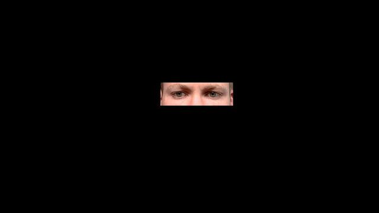

Original Source Frame

**True yaw**1.66 deg

**Old Prediction vs True Yaw**2.68 deg / error 1.02

**New Prediction vs True Yaw**2.43 deg / error 0.77

**New vs Old Predicted Yaw**delta -0.26 deg

**p01-day53-right-00352** +5 deg camera-up effect

Sample 44 / 50 visualized

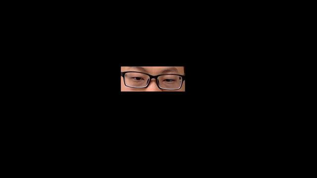

Original Source Frame

**True yaw**1.22 deg

**Old Prediction vs True Yaw**-0.56 deg / error 1.78

**New Prediction vs True Yaw**-0.49 deg / error 1.71

**New vs Old Predicted Yaw**delta +0.07 deg

**p01-day37-right-00396** +5 deg camera-up effect

Sample 45 / 50 visualized

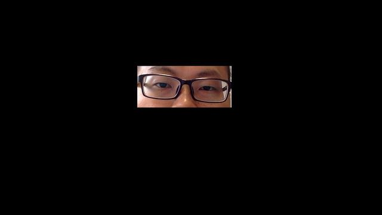

Original Source Frame

**True yaw**1.64 deg

**Old Prediction vs True Yaw**0.95 deg / error 0.69

**New Prediction vs True Yaw**1.35 deg / error 0.29

**New vs Old Predicted Yaw**delta +0.40 deg

**p01-day16-left-00074** +5 deg camera-up effect

Sample 46 / 50 visualized

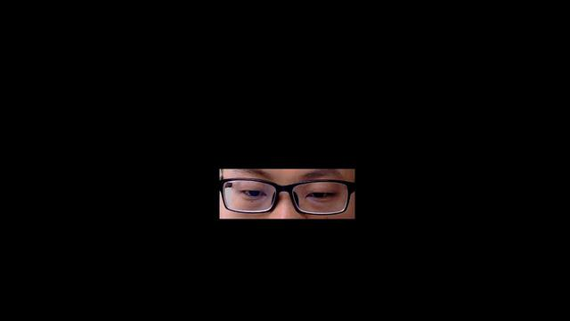

Original Source Frame

**True yaw**5.03 deg

**Old Prediction vs True Yaw**4.23 deg / error 0.80

**New Prediction vs True Yaw**3.42 deg / error 1.61

**New vs Old Predicted Yaw**delta -0.81 deg

**p02-day22-left-00206** +10 deg camera-up effect

Sample 47 / 50 visualized

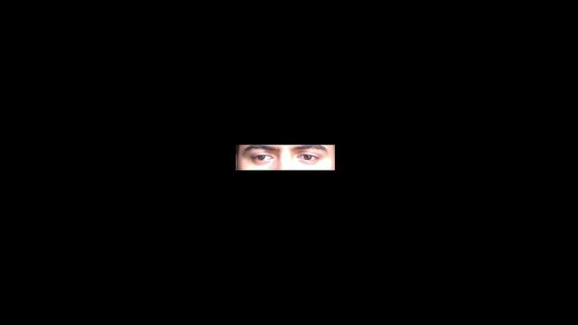

Original Source Frame

**True yaw**9.10 deg

**Old Prediction vs True Yaw**9.37 deg / error 0.27

**New Prediction vs True Yaw**9.29 deg / error 0.19

**New vs Old Predicted Yaw**delta -0.08 deg

**p00-day26-right-00194** +5 deg camera-up effect

Sample 48 / 50 visualized

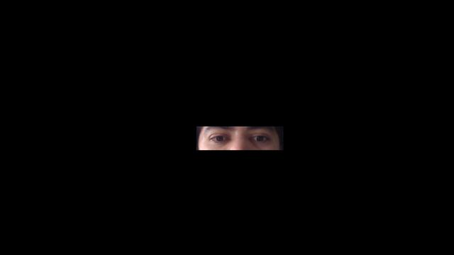

Original Source Frame

**True yaw**-0.54 deg

**Old Prediction vs True Yaw**0.72 deg / error 1.26

**New Prediction vs True Yaw**1.37 deg / error 1.91

**New vs Old Predicted Yaw**delta +0.65 deg

**p01-day10-right-00067** +5 deg camera-up effect

Sample 49 / 50 visualized

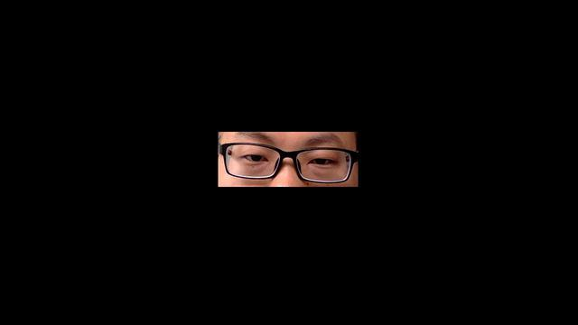

Original Source Frame

**True yaw**1.19 deg

**Old Prediction vs True Yaw**0.25 deg / error 0.94

**New Prediction vs True Yaw**0.75 deg / error 0.44

**New vs Old Predicted Yaw**delta +0.50 deg

**p05-day03-left-00510** +5 deg camera-up effect

Sample 50 / 50 visualized

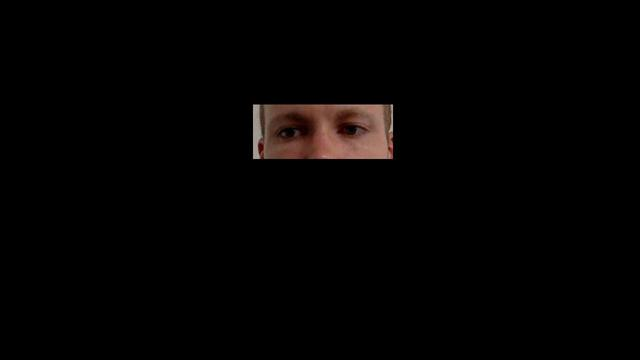

Original Source Frame

**True yaw**9.68 deg

**Old Prediction vs True Yaw**10.69 deg / error 1.01

**New Prediction vs True Yaw**10.23 deg / error 0.55

**New vs Old Predicted Yaw**delta -0.46 deg